# pca.R

ana

Wed Jul 11 14:37:05 2018

# Análisis PCA

Hay que instalar ggplot2 y ggfortify

```r
library(ggfortify)
library(factoextra)
```

## PCA con nuestro dataset

### Carga y procesamiento de datos

```r
library(readr)
library(tibble)
dataset <- read_csv("../data/Miel.concentraciones.en.microgramos.por.gramo.csv")
```

Quitar columnas vacías

```r
vacias <- 29:ncol(dataset)
dataset <- dataset[-vacias]
```

Columna clase o etiqueta

```r
vDeUco <- "Valle de Uco"
add_column(dataset,label=0)
```

```
## # A tibble: 154 x 29
##    `Zona geográfic…      Li    Na    Mg    Al    Ca     Ti       V      Cr
##    <chr>              <dbl> <dbl> <dbl> <dbl> <dbl>  <dbl>   <dbl>   <dbl>
##  1 Valle de Uco     9.95e-2  5.23 26.5  35.4   23.4 0.0930 5.48e-3 3.15e-2
##  2 Valle de Uco     1.00e-4  1.40 77.4   1.71  59.6 0.0541 6.20e-3 1.00e-4
##  3 Valle de Uco     6.86e-2  1.13 80.8   3.54  43.9 0.0246 1.00e-4 5.17e-2
##  4 Valle de Uco     1.82e-1  2.78 11.6   2.84  22.7 0.112  8.78e-3 1.00e-4
##  5 Valle de Uco     7.98e-2  1.19 10.3   2.26  11.9 0.0674 1.74e-3 2.41e-2
##  6 Valle de Uco     6.10e-2  3.70 46.5   1.83  32.7 0.0367 6.53e-5 4.62e-2
##  7 Valle de Uco     3.29e-2  1.64 65.6   2.16  46.3 0.0912 7.19e-3 6.06e-3
##  8 Valle de Uco     6.03e-2  1.70 39.2   5.40  33.2 0.122  4.55e-3 1.12e-2
##  9 Valle de Uco     1.00e-4  3.93 54.7   2.84  44.2 0.0890 1.08e-2 1.00e-4
## 10 Valle de Uco     2.40e-1  1.14  9.23  3.62  18.7 0.0614 1.44e-3 1.40e-2
## # ... with 144 more rows, and 20 more variables: Mn <dbl>, Fe <dbl>,
## #   Co <dbl>, Ni <dbl>, Cu <dbl>, Zn <dbl>, As <dbl>, Se <dbl>, Rb <dbl>,
## #   Sr <dbl>, Mo <dbl>, Pd <dbl>, Ag <dbl>, Cd <dbl>, Sn <dbl>, Sb <dbl>,
## #   Hg <dbl>, `207 Pb` <dbl>, `208 Pb` <dbl>, label <dbl>
```

```r
names(dataset)[1] <- "Zona"
```

Agrego columna Region

```r
dataset[dataset$Zona == vDeUco,"Region"] <- "Valle_de_Uco"
dataset[dataset$Zona != vDeUco,"Region"] <- "Rest_of_Mza"
data <- dataset[,2:(ncol(dataset)-1)] # quito primera y última columna
```

### PCA

Usando factoextra para graficar

```r
pca.model <- prcomp(data,scale. = TRUE)
```

Valores regresados por la funcion prcomp()

```r
names(pca.model)
```

```
## [1] "sdev"     "rotation" "center"   "scale"    "x"
```

sdev : es la desviación estándar de los componenest principales (las raíces cuadradas de los eigenvalues (valores propios))

```r
head(pca.model$sdev)
```

```
## [1] 2.653336 1.887443 1.525749 1.413430 1.208112 1.112275
```

rotación: la matriz de variables “loadings”, columnas que son vectores propios (eigenvectors)

```r
head(unclass(pca.model$rotation)[, 1:4])
```

```
##             PC1          PC2         PC3         PC4
## Li -0.011567301  0.247565891 -0.10662808  0.36449343
## Na  0.033380964  0.223463028 -0.12263191  0.39462538
## Mg  0.326807615  0.054907975 -0.16711886  0.11849397
## Al -0.001013309  0.076048422  0.06305856 -0.08829215
## Ca  0.350959633 -0.002117391 -0.12275329 -0.06837027
## Ti  0.008944374  0.073214981  0.07750544  0.14995980
```

en center y scale se guardan los valores de media y desviación que normalizaron los datos

```r
print(pca.model$center)
```

```
##           Li           Na           Mg           Al           Ca
##  0.067901968  4.003587056 30.092435229  5.613988878 29.118100216
##           Ti            V           Cr           Mn           Fe
##  0.091446547  0.006600364  0.016613510  0.511734863  3.727061577
##           Co           Ni           Cu           Zn           As
##  0.006212591  0.578347280  0.313769718  1.198564309  0.010817276
##           Se           Rb           Sr           Mo           Pd
##  0.009122465  0.338743482  0.557526373  0.013800638  0.024240819
##           Ag           Cd           Sn           Sb           Hg
##  0.006981727  0.002014170  0.177264080  0.036796290  0.022776701
##       207 Pb       208 Pb
##  0.070579878  0.075647280
```

```r
print(pca.model$scale)
```

```
##          Li          Na          Mg          Al          Ca          Ti
##  0.07210078  3.74226686 28.61414193  9.99325019 36.31923381  0.16728823
##           V          Cr          Mn          Fe          Co          Ni
##  0.01383632  0.05182429  0.34738641  2.55750121  0.00640777  3.89621677
##          Cu          Zn          As          Se          Rb          Sr
##  0.29682503  0.52629453  0.02276857  0.01967173  0.35664321  1.19799905
##          Mo          Pd          Ag          Cd          Sn          Sb
##  0.03123979  0.01650863  0.02054773  0.00319651  0.36936741  0.01583423
##          Hg      207 Pb      208 Pb
##  0.03133039  0.14153252  0.14577575
```

Para ver con detalle coordenadas, coseno cuadrado y contribuciones

```r
get_pca_ind(pca.model)
```

```
## Principal Component Analysis Results for individuals
##  ===================================================
##   Name       Description
## 1 "$coord"   "Coordinates for the individuals"
## 2 "$cos2"    "Cos2 for the individuals"
## 3 "$contrib" "contributions of the individuals"
```

Por ejemplo para acceder al cos2 de los individuos usar ´get_pca_ind(pca.model)$cos2´ Eigenvalues y varianza

```r
summary(pca.model)
```

```
## Importance of components:
##                           PC1    PC2     PC3     PC4     PC5     PC6
## Standard deviation     2.6533 1.8874 1.52575 1.41343 1.20811 1.11228
## Proportion of Variance 0.2607 0.1319 0.08622 0.07399 0.05406 0.04582
## Cumulative Proportion  0.2607 0.3927 0.47891 0.55290 0.60696 0.65278
##                            PC7     PC8    PC9    PC10    PC11    PC12
## Standard deviation     1.08942 0.99435 0.9651 0.94171 0.89937 0.85155
## Proportion of Variance 0.04396 0.03662 0.0345 0.03284 0.02996 0.02686
## Cumulative Proportion  0.69674 0.73336 0.7679 0.80070 0.83066 0.85751
##                           PC13    PC14    PC15    PC16    PC17    PC18
## Standard deviation     0.76787 0.75333 0.73614 0.67713 0.63146 0.62225
## Proportion of Variance 0.02184 0.02102 0.02007 0.01698 0.01477 0.01434
## Cumulative Proportion  0.87935 0.90037 0.92044 0.93742 0.95219 0.96653
##                           PC19   PC20   PC21    PC22    PC23    PC24
## Standard deviation     0.53898 0.4929 0.4025 0.29980 0.27875 0.14765
## Proportion of Variance 0.01076 0.0090 0.0060 0.00333 0.00288 0.00081
## Cumulative Proportion  0.97729 0.9863 0.9923 0.99562 0.99850 0.99930
##                           PC25    PC26    PC27
## Standard deviation     0.09679 0.09587 0.01603
## Proportion of Variance 0.00035 0.00034 0.00001
## Cumulative Proportion  0.99965 0.99999 1.00000
```

What mean eigenvalues ? Recall that eigenvalues measures the variability retained by each PC. It’s large for the first PC and small for the subsequent PCs. The importance of princpal components (PCs) can be visualized with a scree plot.

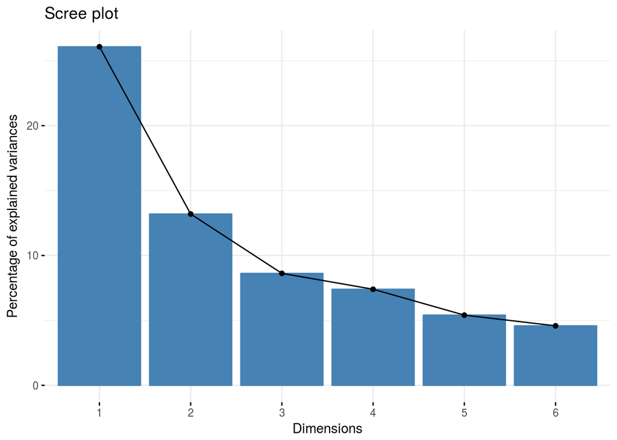

```r
fviz_screeplot(pca.model, ncp=6)
```

How to determine the number of components to retain? An eigenvalue > 1 indicates that PCs account for more variance than accounted by one of the original variables in standardized data. This is commonly used as a cutoff point for which PCs are retained. You can also limit the number of component to that number that accounts for a certain fraction of the total variance. For example, if you are satisfied with 80% of the total variance explained then use the number of components to achieve that. Note that, a good dimension reduction is achieved when the the first few PCs account for a large proportion of the variability (80-90%). ### Graph of variables

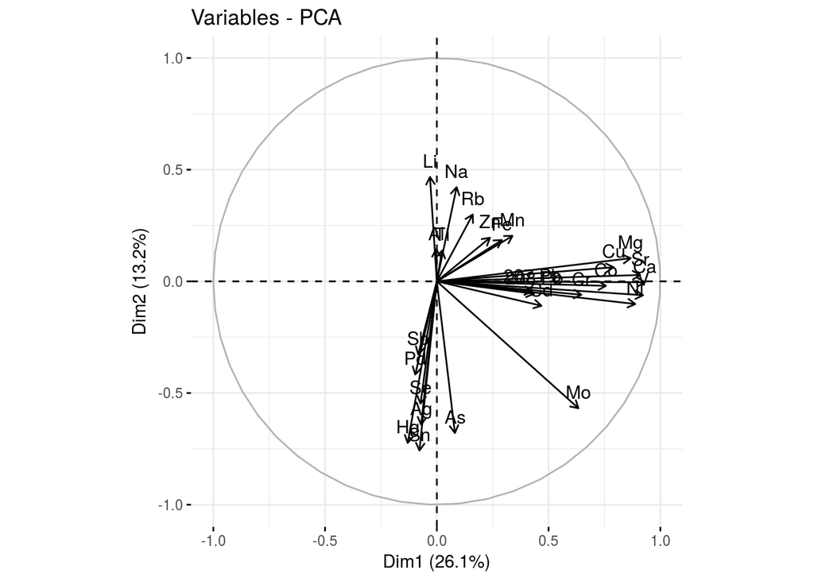

```r
fviz_pca_var(pca.model)
```

mismo gráfico en tono azules

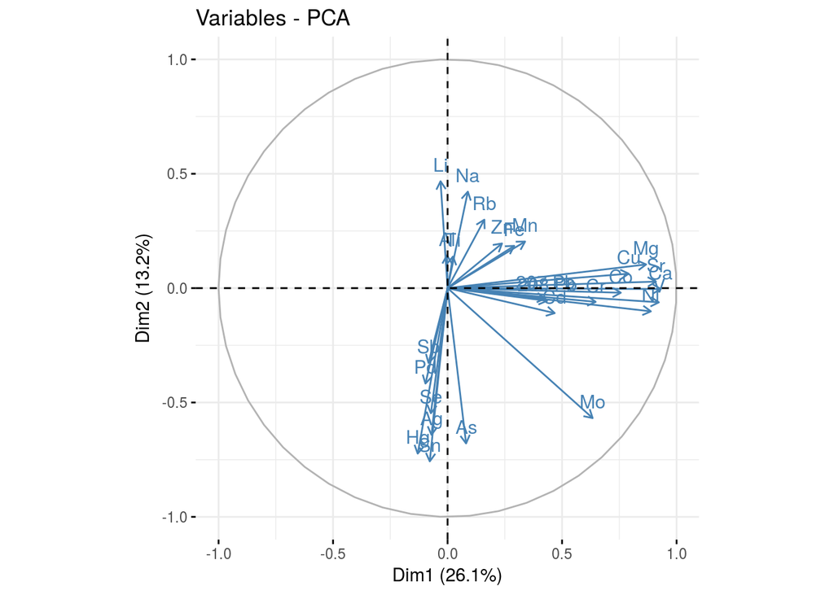

```r
fviz_pca_var(pca.model, col.var = "steelblue")
```

Los colores de las variables varían según su contribución.

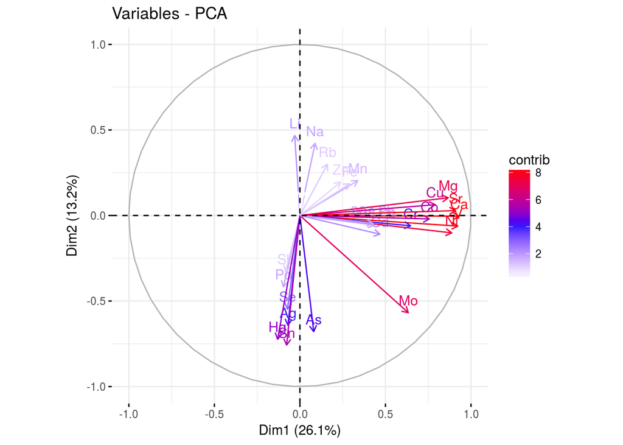

```r
fviz_pca_var(pca.model, col.var = "contrib",
             gradient.cols = c("white", "blue", "red"),
             ggtheme = theme_minimal())
```

Elegimos un variables con el cos2 >= 0.6

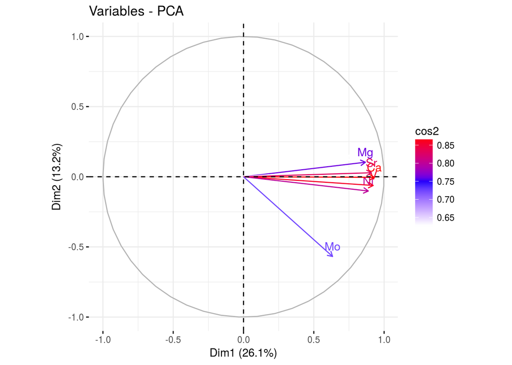

```r
fviz_pca_var(pca.model, col.var = "cos2", select.var = list(cos2=0.6),
             gradient.cols = c("white", "blue", "red"),
             ggtheme = theme_minimal())
```

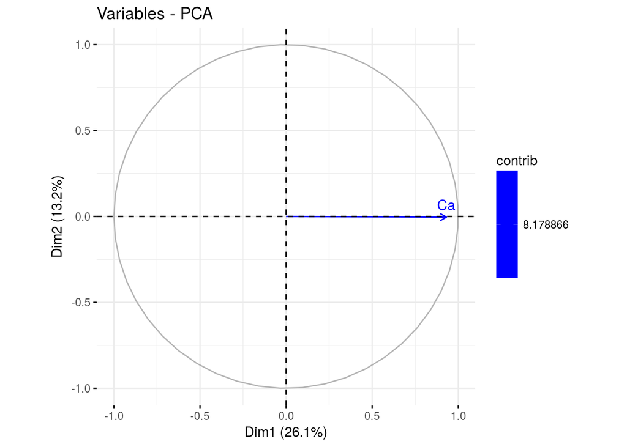

```r
fviz_pca_var(pca.model, col.var = "contrib", select.var = list(contrib=0.6) ,
             gradient.cols = c("white", "blue", "red"),
             ggtheme = theme_minimal())
```

How to interpret the correlation plot? The graph of variables shows the relationships between all variables : Positively correlated variables are grouped together. Negatively correlated variables are positioned on opposite sides of the plot origin (opposed quadrants). The distance between variables and the origine measures the quality of the variables on the factor map. Variables that are away from the origin are well represented on the factor map. ### Gráfico de individuos Usando librería factoextra. Graficamos los individuos mediante puntos, cuyo color varía según el coseno cuadrado (cos2), que representa la calidad de los individuos en el factor map

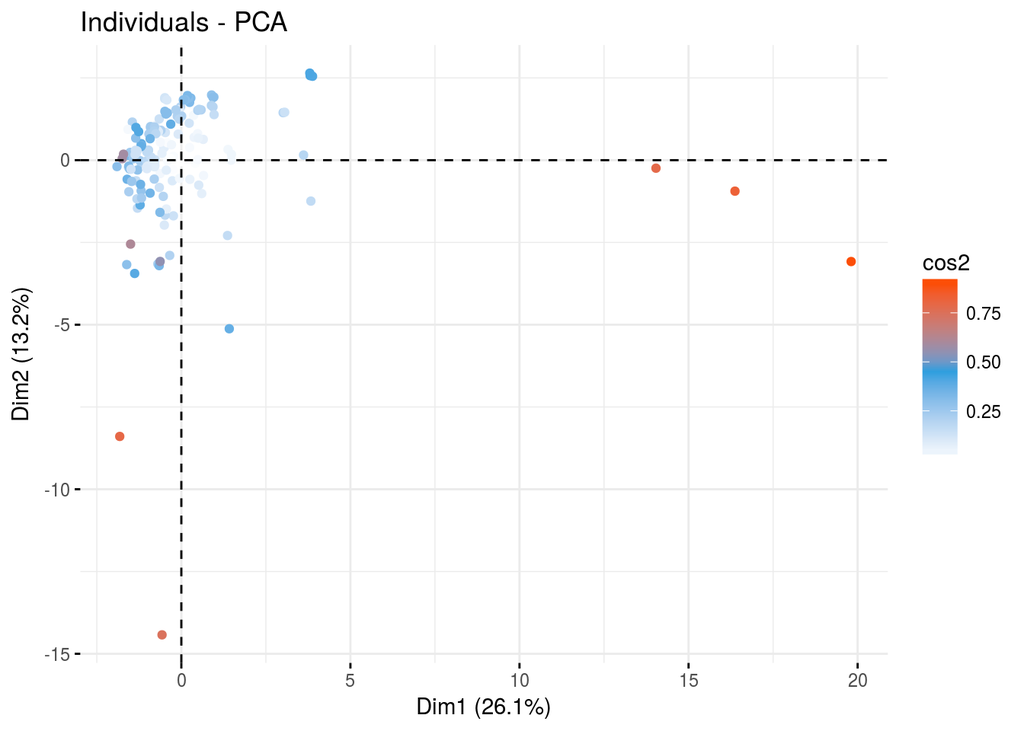

```r
fviz_pca_ind(pca.model, col.ind="cos2", geom = "point",
             gradient.cols = c("white", "#2E9FDF", "#FC4E07" ))
```

Coloreamos individuos por grupos (son de VAlle de Uco o no). Sobre colores, ver RColorBrewer

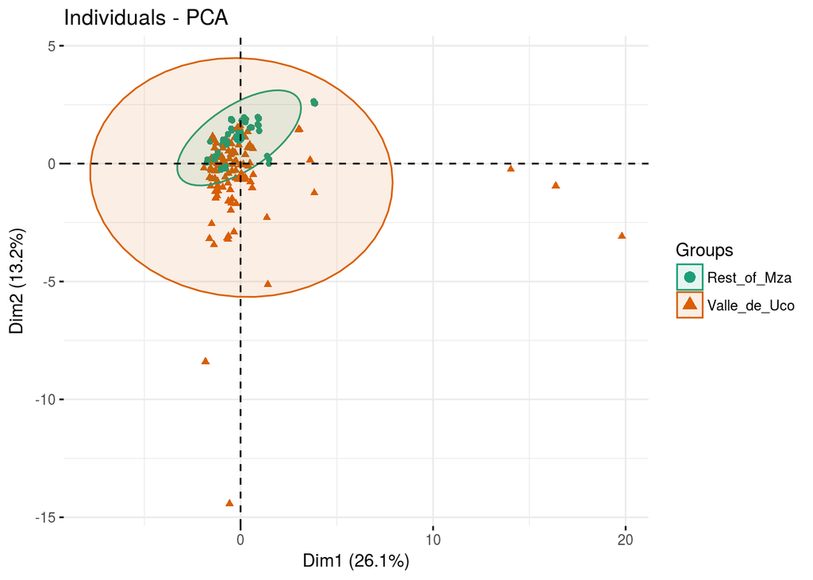

```r
fviz_pca_ind(pca.model, label="none", habillage=dataset$Region,
             addEllipses=TRUE, ellipse.level=0.95, palette = "Dark2")
```

O podemos cambiar los colores usando una paleta de colores definida por uno mismo.

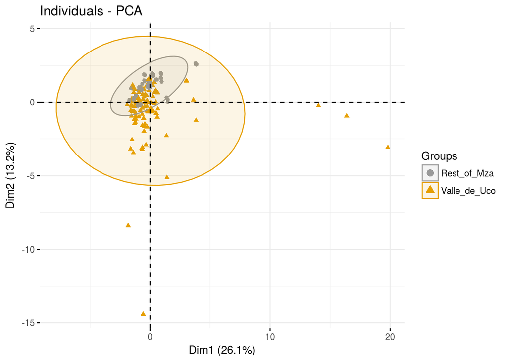

```r
fviz_pca_ind(pca.model, label="none", habillage=dataset$Region,
             addEllipses=TRUE, ellipse.level=0.95, palette = c("#999999", "#E69F00", "#56B4E9"))
```

con ggfortify

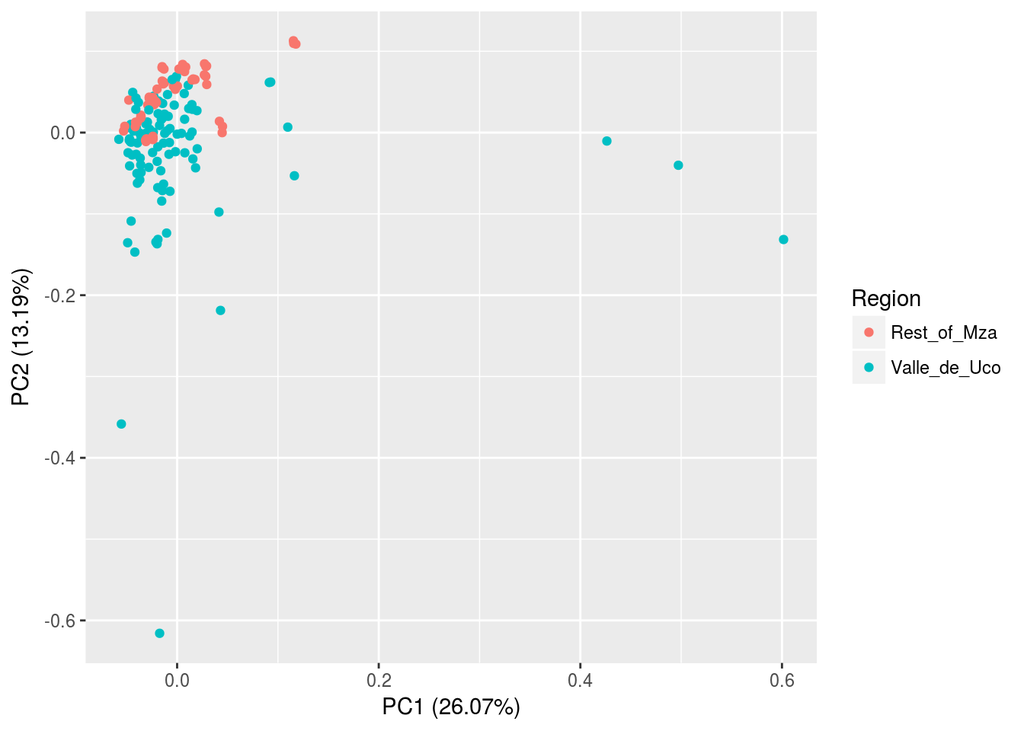

```r
autoplot(pca.model,data=dataset,colour = 'Region')
```

## Biplot de individuos y variables

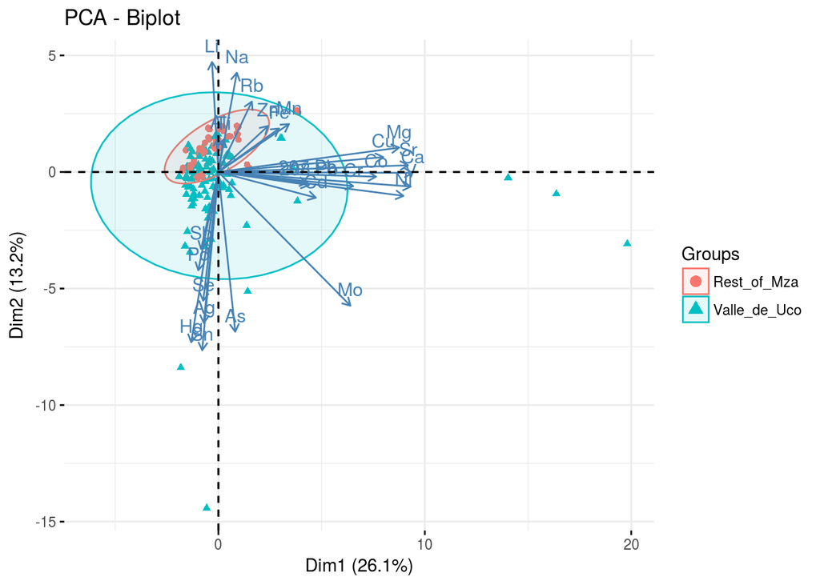

```r
fviz_pca_biplot(pca.model, label = "var", habillage=dataset$Region,
                addEllipses=TRUE, ellipse.level=0.85,
                ggtheme = theme_minimal())
```

usando librería ggfortify, gráfico individuos + loadings

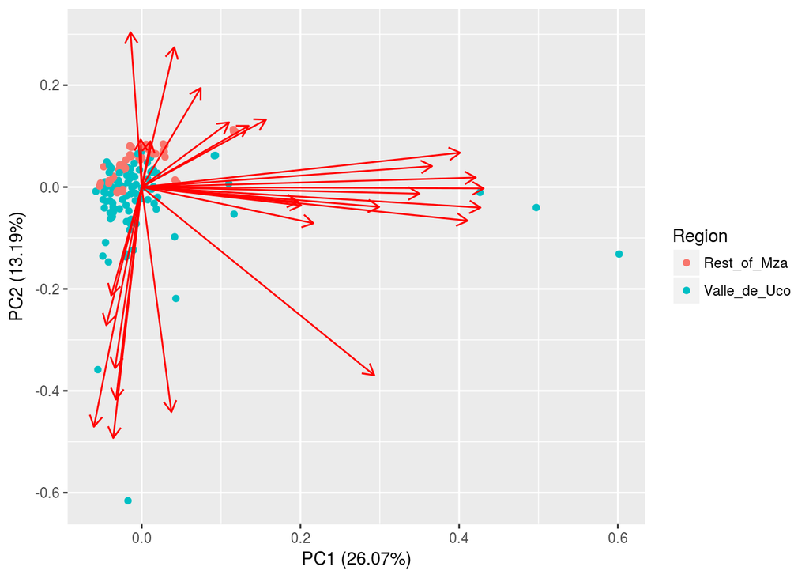

```r
autoplot(pca.model,data=dataset,colour = 'Region',loadings = TRUE)
```

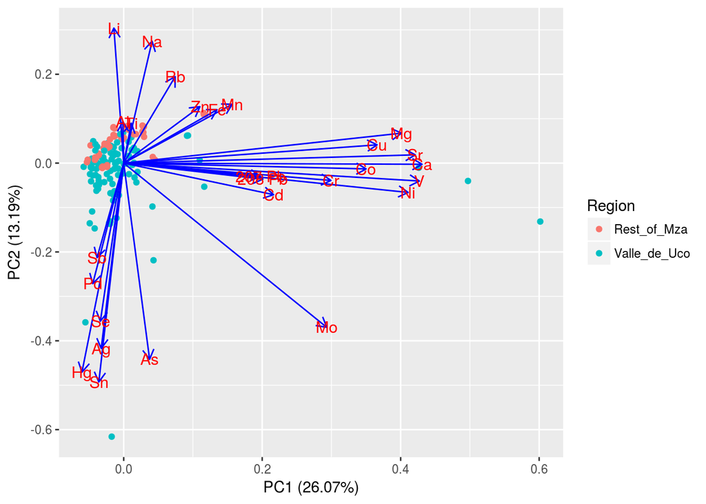

```r
autoplot(pca.model,data=dataset,colour = 'Region',
         loadings = TRUE, loadings.colour = 'blue',
         loadings.label = TRUE, loadings.label.size = 4)
```

con librería DataExplorer

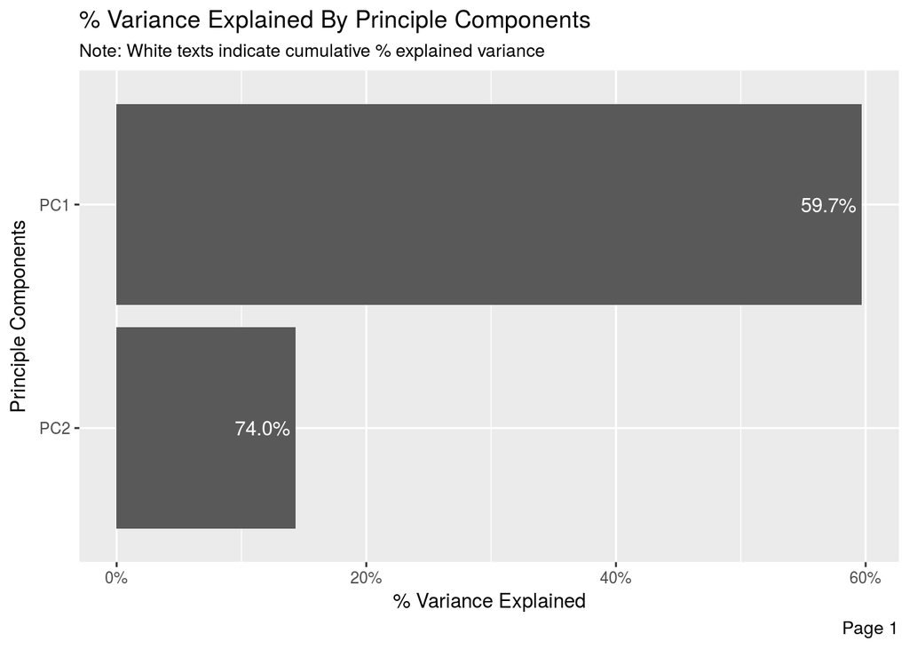

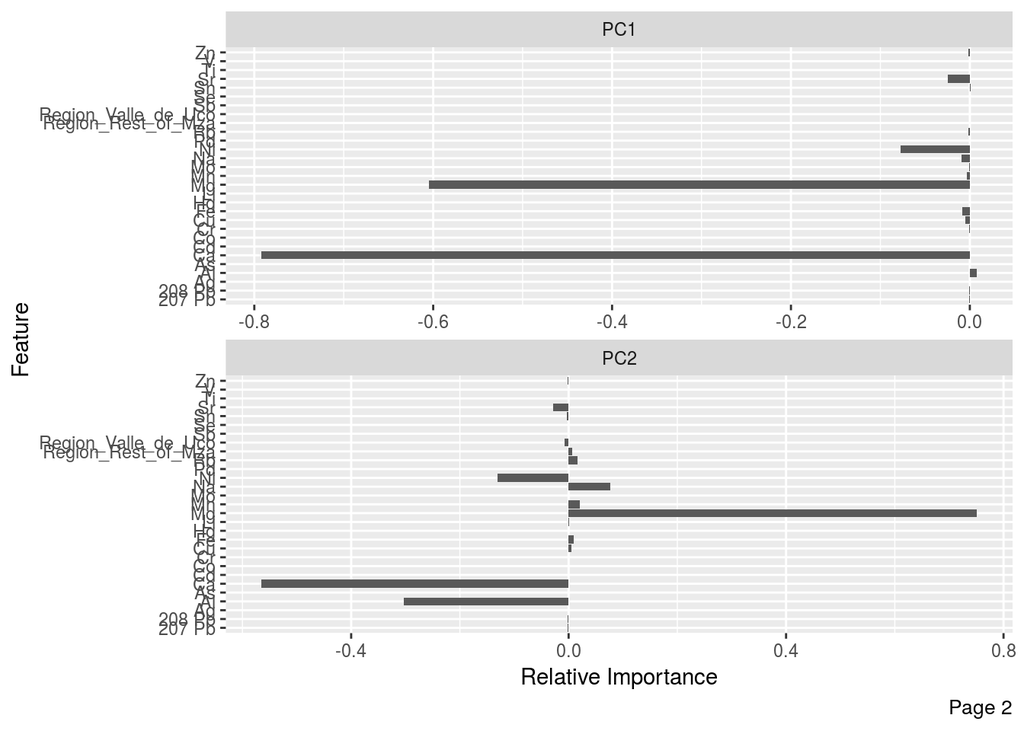

```r
library(DataExplorer)

plot_prcomp(dataset[-1])
```

más ejemplos en https://cran.r-project.org/web/packages/ggfortify/vignettes/plot_pca.html